# Deep Learning workflow for gully mapping

We first define paths to the reference data and the images to use for training the model. We will also define a directory where the output is stored. Basic steps ae taken from the [Deep Learning - Object Detection guide](https://github.com/Esri/arcgis-python-api/blob/master/guide/14-deep-learning/object-detection.ipynb)

We can then call the required modules to start the processing.

```python
# Import system modules and check out ArcGIS Image Analyst extension license
import arcpy
arcpy.CheckOutExtension("ImageAnalyst")
from arcpy.ia import *
from arcpy import env
import os
data_dir = 'e:/Lorena/ArcPy/data/'
env.workspace = data_dir
env.scratchWorkspace = data_dir
env.parallelProcessingFactor = 0
```

## Data pre-processing

We will next combine the terrain derivatives calculated from the LiDAR DEM data into a single raster with different layers.

The next two cells only need to be run once!

```python
arcpy.CompositeBands_management(
    "mangatu_cplan.tif;mangatu_cprof.tif;mangatu_ddgrd.tif;mangatu_lsfct.tif;mangatu_mbidx.tif;mangatu_shade.tif;mangatu_slope.tif;mangatu_spidx.tif;mangatu_textu.tif;mangatu_tridx.tif;mangatu_twidx.tif;mangatu_vdcnw.tif",
    "terrain.tif"
)
```

Messages

Rename raster bands

```python
terrain = r'data\terrain.tif'
terrain_raster = Raster(terrain, True)

terrain_raster.renameBand(1, 'cplan')
terrain_raster.renameBand(2, 'cprof')
terrain_raster.renameBand(3, 'ddgrd')
terrain_raster.renameBand(4, 'lsfct')
terrain_raster.renameBand(5, 'mbidx')
terrain_raster.renameBand(6, 'shade')
terrain_raster.renameBand(7, 'slope')
terrain_raster.renameBand(8, 'spidx')
terrain_raster.renameBand(9, 'textu')
terrain_raster.renameBand(10, 'tridx')
terrain_raster.renameBand(11, 'twidx')
terrain_raster.renameBand(12, 'vdcnw')
terrain_raster.getRasterBands()
```

We will set some paths for our training data and results

```python
terrain = r'data\terrain.tif'
terrain_raster = Raster(terrain, True)
gullies = r'data\gullies_train_union.shp'
```

Select only certain bands for training

```python
bands_sel = ['cplan','lsfct','slope','tridx','twidx']
terrain_sel = ExtractBand(terrain_raster, band_names=bands_sel)
terrain_sel.save('data/temp/terrain_'+''.join(bands_sel)+'.tif')
```

Now we can convert the data to 8BIT. This would ideally standardized the values between 0 and 255 and allow for a better training later on.

```python
nd_val = -99999
# nd_val = -3.402823e+38
terrain_8bit = "temp/terrain_" + ''.join(bands_sel) + "_8bit.tif"
print(terrain_sel)
print(terrain_8bit)
```

```
E:\Lorena\ArcPy\data\temp\terrain_cplanlsfctslopetridxtwidx.tif
temp/terrain_cplanlsfctslopetridxtwidx_8bit.tif
```

```python
arcpy.CopyRaster_management(
    in_raster=terrain_sel,
    out_rasterdataset=terrain_8bit,
    nodata_value=nd_val,
    pixel_type="8_BIT_UNSIGNED",
    # For some reason, actually activating this option DOES NOT scale the pixels
    scale_pixel_value="NONE",
    format= "TIFF")
```

Messages

## Export training data

```python
## Set dir for chip generation named after band selection
out_chips = 'work/terrain_'+ ''.join(bands_sel)
# Create output_dir if not existing
if not os.path.exists(out_chips):
    os.mkdir(out_chips)
print(out_chips)
```

```
work/terrain_cplanlsfctslopetridxtwidx
```

```python
# Execute
ExportTrainingDataForDeepLearning(
    terrain_8bit, out_chips, gullies,
    "TIFF", 1024, 1024, 512, 512,
    "ONLY_TILES_WITH_FEATURES", "RCNN_Masks", 0, "",
    0, None, 90, "MAP_SPACE", "PROCESS_AS_MOSAICKED_IMAGE",
    "NO_BLACKEN", "FIXED_SIZE"
)
```

Messages

The next step is to prepare the data in a format that the models can understand. The data preparation includes splitting between training and testing sets during model training. The batch size is reduced from the default 64 due to memory issues.

```python
from arcgis.learn import prepare_data
data = prepare_data(
    out_chips,
    dataset_type='RCNN_Masks',
    batch_size=4, chip_size=512,
    imagery_type='ms',
    norm_pct=1
)
```

```python
print(data)
```

```
ImageDataBunch;

Train: LabelList (2045 items)
x: ArcGISInstanceSegmentationItemList
ArcGISMSImage (5, 512, 512),ArcGISMSImage (5, 512, 512),ArcGISMSImage (5, 512, 512),ArcGISMSImage (5, 512, 512),ArcGISMSImage (5, 512, 512)
y: ArcGISSegmentationLabelList
ArcGISImageSegment (1, 512, 512),ArcGISImageSegment (1, 512, 512),ArcGISImageSegment (1, 512, 512),ArcGISImageSegment (1, 512, 512),ArcGISImageSegment (1, 512, 512)
Path: work\terrain_cplanlsfctslopetridxtwidx\images;

Valid: LabelList (227 items)
x: ArcGISInstanceSegmentationItemList
ArcGISMSImage (5, 512, 512),ArcGISMSImage (5, 512, 512),ArcGISMSImage (5, 512, 512),ArcGISMSImage (5, 512, 512),ArcGISMSImage (5, 512, 512)
y: ArcGISSegmentationLabelList
ArcGISImageSegment (1, 512, 512),ArcGISImageSegment (1, 512, 512),ArcGISImageSegment (1, 512, 512),ArcGISImageSegment (1, 512, 512),ArcGISImageSegment (1, 512, 512)
Path: work\terrain_cplanlsfctslopetridxtwidx\images;

Test: None
```

We can take a look at a sample of the chips generated:

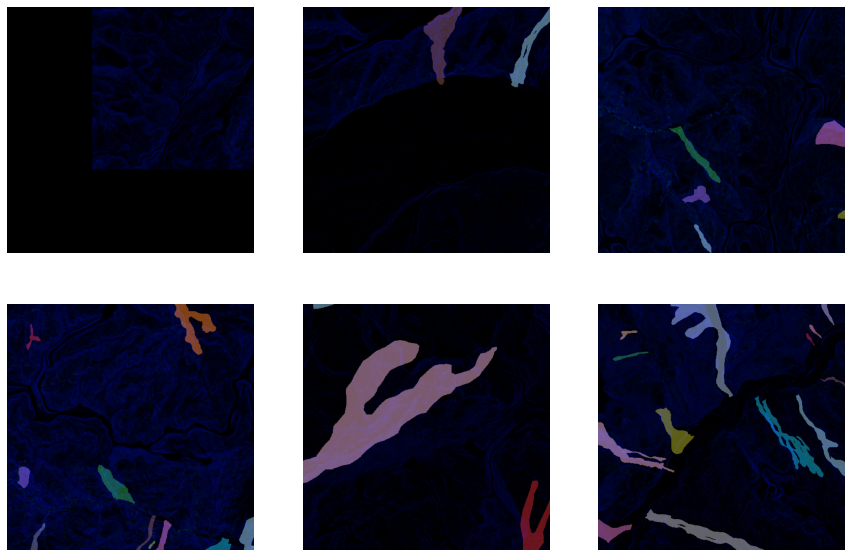

```python
data.show_batch(rgb_bands=[0,1,2])
```

## Model training

Before any training, let's make sure the CUDA memory is at its max.

```python
import torch
torch.cuda.empty_cache()
torch.cuda.is_available()
```

```
True
```

Defining a model architecture:

```python
from arcgis.learn import MaskRCNN
maskrcnn = MaskRCNN(
    data, backbone='resnet50', pointrend=False
)
```

Finding the efficient learning rate:

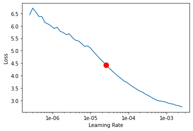

```
2.5118864315095795e-05
```

```python
maskrcnn.lr_find()
```

Now we can use the found learning rate to fit the model.

```python
maskrcnn.fit(epochs=25,early_stopping=True,lr=2.5118864315095795e-05)
```

```
epoch     train_loss  valid_loss  time
0         1.299867    1.284703    18:00
1         1.099927    1.169155    17:50
2         1.070166    1.121608    17:26
3         1.065797    1.165281    18:02
4         1.014649    1.095836    18:17
5         1.026133    1.116939    18:15
6         1.005487    1.152197    17:58
7         0.968275    1.131736    17:50
8         0.988010    1.088261    18:39
9         0.963028    1.043123    17:56
10        0.942839    1.013719    17:39
11        0.944294    1.025074    17:36
12        0.951483    0.981668    17:39
13        0.926265    0.987638    17:40
14        0.941493    0.970672    17:56
15        0.907088    0.977851    17:45
16        0.882210    0.986335    17:46
17        0.856885    0.951432    17:35
18        0.861350    0.942161    17:41
19        0.840727    0.930165    17:46
20        0.854560    0.909695    17:48
21        0.860659    0.921618    17:47
22        0.831288    0.911453    18:05
23        0.850530    0.916858    17:43
24        0.852879    0.916000    17:56
```

```python
maskrcnn.unfreeze()
```

```python
model_name = '25ep'
maskrcnn.save(model_name)
```

```
Computing model metrics...
█
```

```
WindowsPath('E:/Lorena/ArcPy/work/terrain_cplanlsfctslopetridxtwidx/models/25ep')
```

We will take a look at train and validation loss curves to check if the model is underfitting, overfitting and if the data is representative. A guide for this intepretation [can be found here](https://www.baeldung.com/cs/learning-curve-ml), [here](https://rstudio-conf-2020.github.io/dl-keras-tf/notebooks/learning-curve-diagnostics.nb.html) and [here](https://machinelearningmastery.com/learning-curves-for-diagnosing-machine-learning-model-performance/).

```python
maskrcnn.learn.recorder.plot_losses()
```

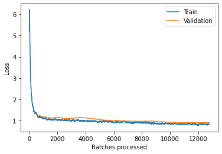

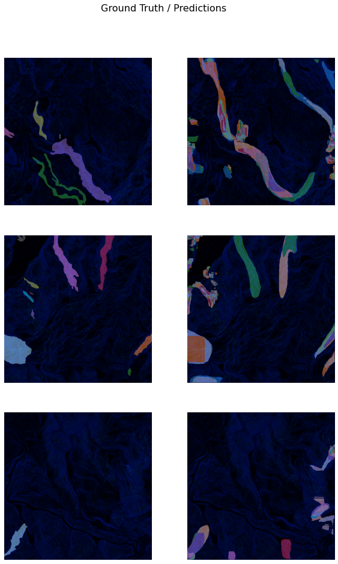

```python
maskrcnn.show_results(rows=3)
```

## Detect objects

Sadly, this section here does not work with code, so for now, please go to the Geoprocessing tool :)

```python
arcpy.env.processorType = "GPU"
```

```python
model_name = '5ep'
terrain_8bit = 'temp/terrain_lsfctslopetridxtwidx_8bit.tif'
# Create output_dir if not existing
if not os.path.exists(os.path.join(out_chips, "results")):
    os.mkdir(os.path.join(out_chips, "results"))

# Set local variables
in_raster = terrain_8bit
out_detected_objects = os.path.join(out_chips, "results", "gully_" + model_name + ".shp")
in_model_definition = os.path.join(out_chips, "models", model_name, model_name + ".emd")
model_arguments = "padding 128;threshold 0.5;batch_size 4;tile_size 512"
run_nms = "NO_NMS"
confidence_score_field = "Confidence"
class_value_field = "Class"
max_overlap_ratio = 0
processing_mode = "PROCESS_AS_MOSAICKED_IMAGE"

# Check out the ArcGIS Image Analyst extension license
arcpy.CheckOutExtension("ImageAnalyst")

# Execute
DetectObjectsUsingDeepLearning(in_raster, out_detected_objects,
   in_model_definition, model_arguments, run_nms, confidence_score_field,
   class_value_field, max_overlap_ratio, processing_mode)
```

```
AttributeError: 'ArcGISInstanceDetector' object has no attribute 'updatePixels'
```

[output not shown]

```python
from arcgis.learn import detect_objects
from arcgis.gis import GIS
model_name = '5ep'
out_chips='work/terrain_lsfctslopetridxtwidx'
terrain_8bit = 'temp/terrain_lsfctslopetridxtwidx_8bit.tif'
# Create output_dir if not existing
if not os.path.exists(os.path.join(out_chips, "results")):
    os.mkdir(os.path.join(out_chips, "results"))
gis_zgis=GIS(url='https://zgis.maps.arcgis.com')
```

```python
# Set local variables
in_raster = terrain_8bit
out_detected_objects = os.path.join(out_chips, "results", "gully_" + model_name + ".shp")
in_model_definition = os.path.join(out_chips, "models", model_name, model_name + ".emd")
model_arguments = "padding 128;threshold 0.5;batch_size 4;tile_size 512"
# run_nms = "NO_NMS"
confidence_score_field = "Confidence"
class_value_field = "Class"
max_overlap_ratio = 0
# processing_mode = "PROCESS_AS_MOSAICKED_IMAGE"

# Execute
detect_objects(
    input_raster=in_raster,
    model=in_model_definition,
    model_arguments=model_arguments,
    output_name=out_detected_objects,
    run_nms=False,
    confidence_score_field = "Confidence",
    class_value_field = "Class",
    max_overlap_ratio = 0,
    context={"processorType": "GPU"},
    process_all_raster_items=False,
    gis = gis_zgis
)
```

[output not shown]